# User_analysis

qingye

# 本报告对2017-12-08用户至2017-12-19这两周的行为进行了分析

#### 包括反映用户数目的UV,反映用户活跃度的：人均PV,用户活跃时长,以及反映用户黏度的次日留存，本次报告加入了路径深度的分析,加入了转化部分,并采用多种方式作图

#### 本次报告用R语言自动化生成报告的框架搭建，今后将在此基础上不断改进优化

## 近两周的日活跃度(UV)

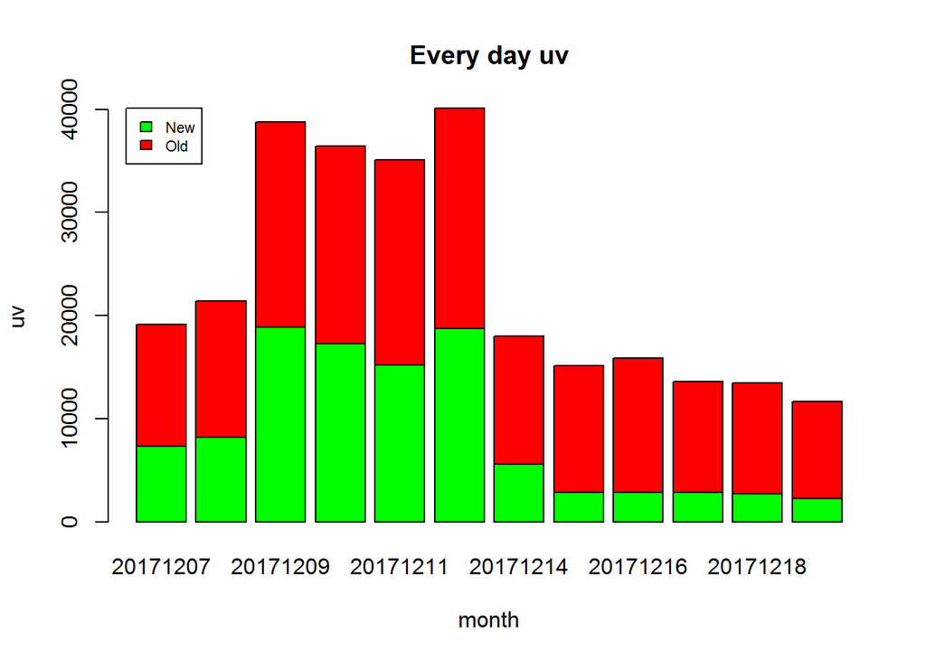

平均UV为23225,

最大UV为40115,

最大值发生在20171212

有0 天新用户在UV值上超过老用户

20171209 用户UV明显高于平均值 20171215 用户UV明显低于平均值

## 近两周人均PV

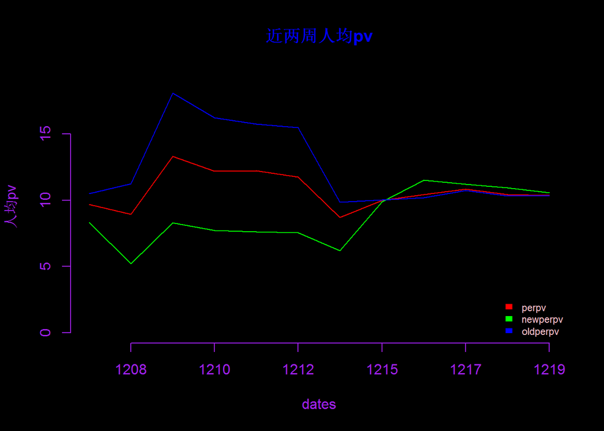

总体PV均值为10.7323248

总体PV最大值为13.3035221 最大值发生在 20171209

总体PV最小值为8.7144999 最小值发生在 20171214

新用户PV均值为8.7423965

新用户PV最大值为11.5021142 最大值发生在 20171216

新用户PV最小值为5.2020498 最小值发生在 20171208

老用户PV均值为12.38239

老用户PV最大值为18.0634266 最大值发生在 20171209

老用户PV最小值为9.8627815 最小值发生在 20171214

有4 天新用户在人均PV值上超过老用户

20171208, 20171217, 20171219 新用户和老用户的趋势不一样

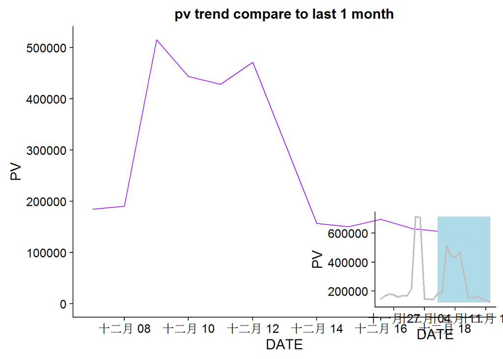

画中画分析，大图，小图中高亮处均表示示近两周pv趋势，而小图整体表示近一个月的pv情况

12月9日，12月12日出现峰值

12月10日，12月11日出现次峰值

## 用户活跃时长

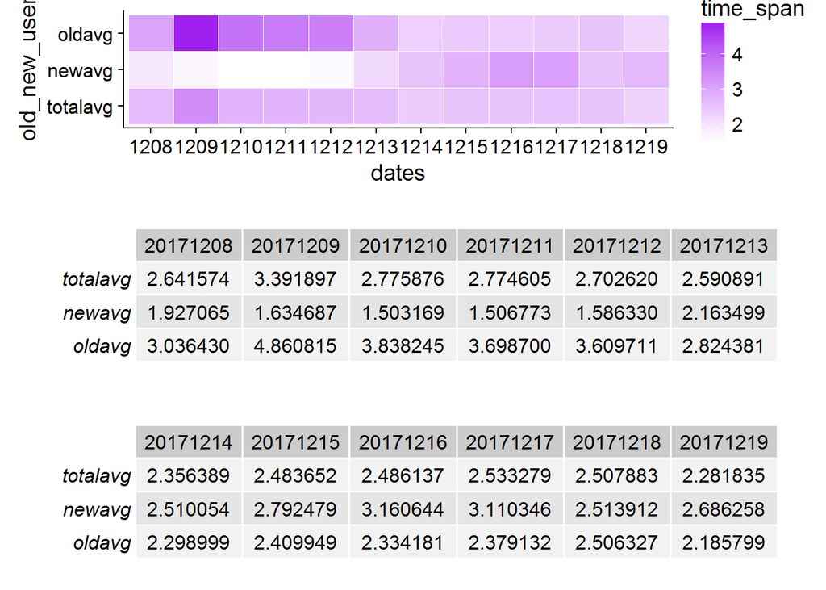

对于用户访问时长作的热力图，

这两周大部分时间新老用户时间差距大，新用户访问时间较短（近乎白色）,尤其是从12月8日到12月12日

但新用户在12月14日到12月19日访问时间较长，几乎超过老用户

老用户在12月9日到12月12日访问时间较长

## 次日留存

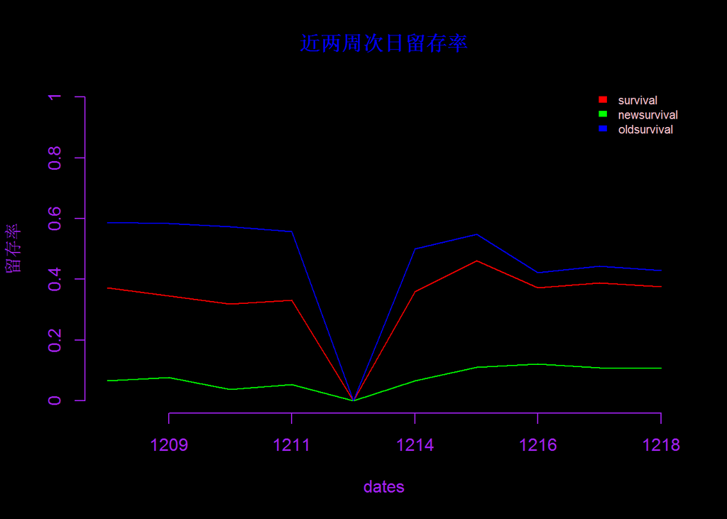

次日留存率，老用户有明显的波动

12月13日，数据有一定缺失

## 新老用户访问平均深度（按用户）

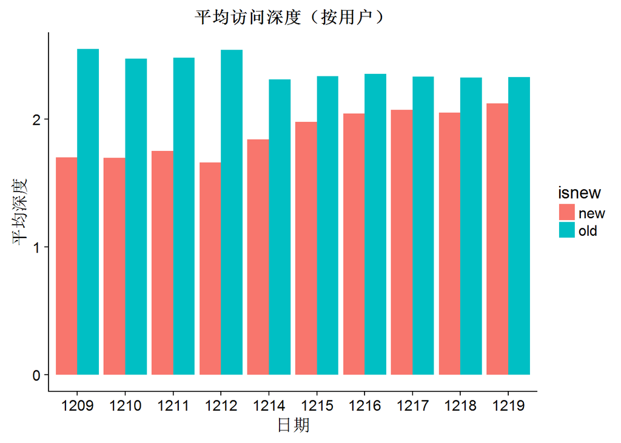

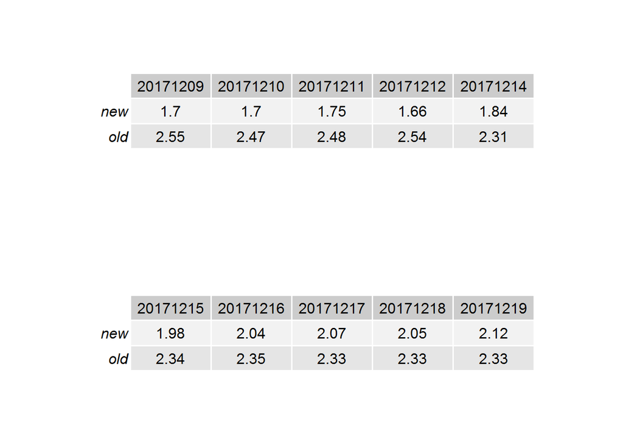

老用户访问深度几乎总大于2，新用户访问深度大部分小于2

从12月14日之前，新老用户访问深度差距较大

[figure not shown]

总体来看，新老用户访问深度差异明显

## 新用户不同机型分布

|  | sym | model | 2017-12-08 | 2017-12-09 | 2017-12-10 | 2017-12-11 | 2017-12-12 | 2017-12-13 | 2017-12-14 | 2017-12-15 | 2017-12-16 | 2017-12-17 | 2017-12-18 | 2017-12-19 | sum | rank |
| --- | --- | --- | --- | --- | --- | --- | --- | --- | --- | --- | --- | --- | --- | --- | --- | --- |
| 1 | 20▲ | 2014813 | 20 | 55 | 40 | 32 | 50 | 15 | 15 | 14 | 15 | 10 | 14 | 12 | 292 | 54 |
| 2 | 450▲ | 6607 | 1 | 46 | 49 | 41 | 43 | 11 | 11 | 5 | 6 | 9 | 7 | 2 | 231 | 83 |
| 3 | -21▼ | BLN-AL10 | 27 | 25 | 31 | 23 | 16 | 11 | 15 | 14 | 17 | 20 | 10 | 8 | 217 | 95 |
| 4 | 7▲ | DUK-AL20 | 17 | 52 | 61 | 28 | 20 | 9 | 18 | 27 | 25 | 20 | 18 | 11 | 306 | 53 |
| 5 | 498▲ | E3 |  | 80 | 51 | 68 | 71 | 3 |  |  |  |  |  |  | 273 | 60 |
| 6 | 498▲ | E3T |  | 56 | 58 | 51 | 59 | 5 |  |  |  |  |  |  | 229 | 84 |
| 7 | 421▲ | E6mini |  | 53 | 56 | 48 | 48 | 9 |  |  |  |  |  |  | 214 | 97 |
| 8 | -1▼ | EVA-AL10 | 18 | 41 | 31 | 28 | 29 | 9 | 26 | 16 | 20 | 17 | 14 | 18 | 267 | 65 |
| 9 | 57▲ | F103 | 4 | 72 | 68 | 39 | 52 | 18 | 1 | 4 | 3 | 4 | 3 | 2 | 270 | 62 |
| 10 | 18▲ | FRD-AL10 | 17 | 24 | 62 | 37 | 23 | 14 | 14 | 17 | 13 | 19 | 17 | 16 | 273 | 61 |

[output cut: 90 more lines]

iphone和vivo手机仍然排名前列，前十名全部被iphone系列手机占据

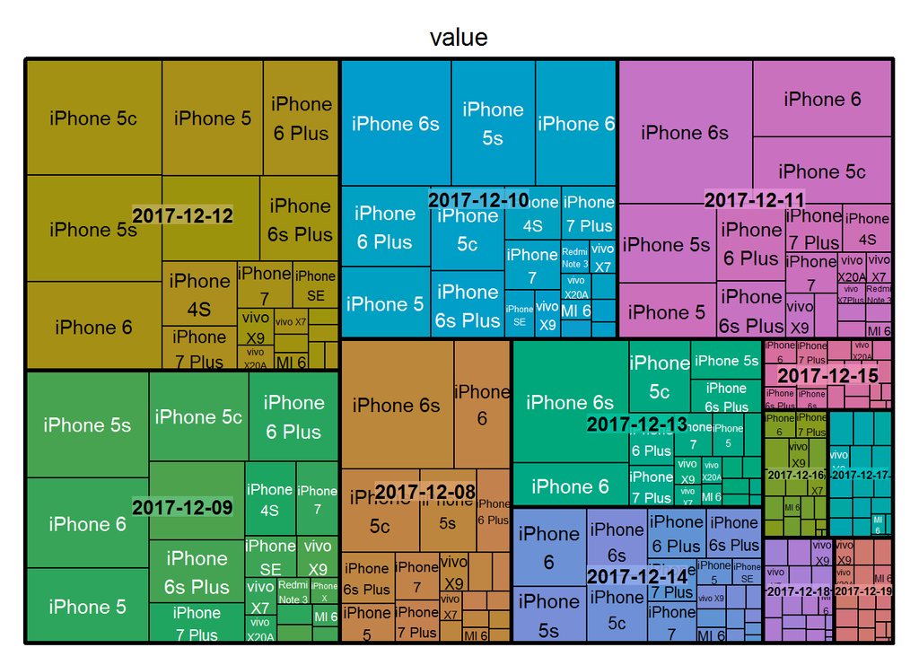

结构矩形树图，大矩形为日期，小矩形为具体机型，按从大到小的顺序，从上到下，从左到右排列

## 新用户不同城市分布

|  | sym | city | 2017-12-08 | 2017-12-09 | 2017-12-10 | 2017-12-11 | 2017-12-12 | 2017-12-13 | 2017-12-14 | 2017-12-15 | 2017-12-16 | 2017-12-17 | 2017-12-18 | 2017-12-19 | sum | rank |
| --- | --- | --- | --- | --- | --- | --- | --- | --- | --- | --- | --- | --- | --- | --- | --- | --- |
| 1 | 1▲ | 上海 | 554 | 1719 | 1783 | 2433 | 3431 | 434 | 213 | 242 | 279 | 247 | 191 | 167 | 11693 | 1 |
| 2 | 1▲ | 北京 | 372 | 766 | 498 | 332 | 308 | 180 | 196 | 238 | 377 | 364 | 276 | 234 | 4141 | 2 |
| 3 | 3▲ | 漯河 | 9 | 775 | 1107 | 671 | 732 | 155 | 4 | 3 | 4 |  | 4 | 1 | 3465 | 3 |
| 4 | 0 | 南京 | 228 | 688 | 601 | 376 | 443 | 108 | 108 | 174 | 193 | 140 | 95 | 78 | 3232 | 4 |
| 5 | 17▲ | 重庆 | 140 | 1051 | 206 | 294 | 293 | 139 | 102 | 70 | 48 | 115 | 108 | 66 | 2632 | 5 |
| 6 | -5▼ | 苏州 | 110 | 286 | 263 | 231 | 655 | 100 | 101 | 72 | 108 | 119 | 191 | 183 | 2419 | 6 |
| 7 | -2▼ | 沈阳 | 103 | 467 | 189 | 495 | 234 | 84 | 230 | 77 | 82 | 88 | 102 | 79 | 2230 | 7 |
| 8 | 0 | 合肥 | 108 | 510 | 299 | 433 | 405 | 66 | 57 | 43 | 47 | 74 | 46 | 37 | 2125 | 8 |
| 9 | -2▼ | 无锡 | 65 | 315 | 406 | 359 | 424 | 71 | 92 | 133 | 76 | 63 | 56 | 52 | 2112 | 9 |
| 10 | 5▲ | 温州 | 227 | 218 | 326 | 459 | 426 | 220 | 137 | 20 | 21 | 11 | 12 | 13 | 2090 | 10 |

[output cut: 91 more lines]

湖州，重庆排名出现大幅提升，值得留意 上海，北京，漯河！？占据前三名

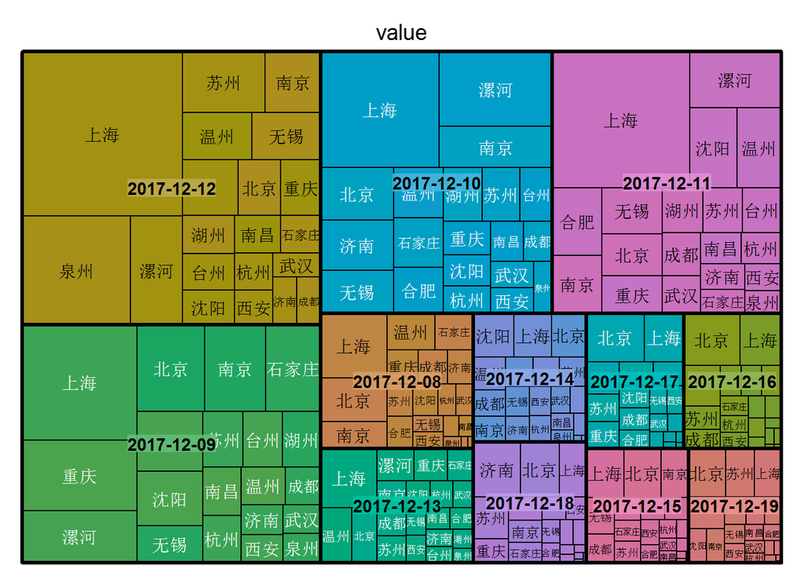

结构矩形树图，大矩形为日期，小矩形为具体城市，按从大到小的顺序，从上到下，从左到右排列

## 新用户不同渠道分布

|  | channels | 2017-12-08 | 2017-12-09 | 2017-12-10 | 2017-12-11 | 2017-12-12 | 2017-12-13 | 2017-12-14 | 2017-12-15 | 2017-12-16 | 2017-12-17 | 2017-12-18 | 2017-12-19 | sum |
| --- | --- | --- | --- | --- | --- | --- | --- | --- | --- | --- | --- | --- | --- | --- |
| 1 | Appstore | 5160 | 4681 | 4405 | 4912 | 4485 | 4512 | 3370 | 475 | 465 | 483 | 345 | 288 | 33581 |
| 2 | 二维码-Android | 120 | 4270 | 4056 | 3885 | 5186 | 572 | 67 | 76 | 157 | 76 | 171 | 101 | 18737 |
| 3 | 二维码-IOS | 186 | 4899 | 4313 | 2444 | 4584 | 39 | 70 | 140 | 127 | 63 | 110 | 91 | 17066 |
| 4 | 30015 | 50 | 2170 | 1915 | 1401 | 2095 | 107 | 52 | 23 | 33 | 31 | 34 | 18 | 7929 |
| 5 | 360手助 | 1017 | 739 | 698 | 706 | 617 | 463 | 480 | 621 | 440 | 421 | 443 | 308 | 6953 |
| 6 | vivo | 630 | 704 | 669 | 608 | 655 | 472 | 451 | 450 | 463 | 435 | 395 | 383 | 6315 |
| 7 | 小米 | 421 | 545 | 481 | 337 | 436 | 468 | 439 | 441 | 420 | 457 | 404 | 388 | 5237 |
| 8 | 华为 | 231 | 322 | 318 | 278 | 199 | 156 | 196 | 168 | 181 | 231 | 188 | 161 | 2629 |
| 9 | 百度手助 | 107 | 151 | 69 | 158 | 251 | 297 | 355 | 284 | 263 | 255 | 234 | 189 | 2613 |
| 10 | 二维码-其他 | 78 | 164 | 186 | 354 | 133 | 20 | 25 | 38 | 36 | 38 | 64 | 33 | 1169 |

[output cut: 21 more lines]

扫码加入是主流方式，IOS app store上新用户流量最多，30015并未进入前三

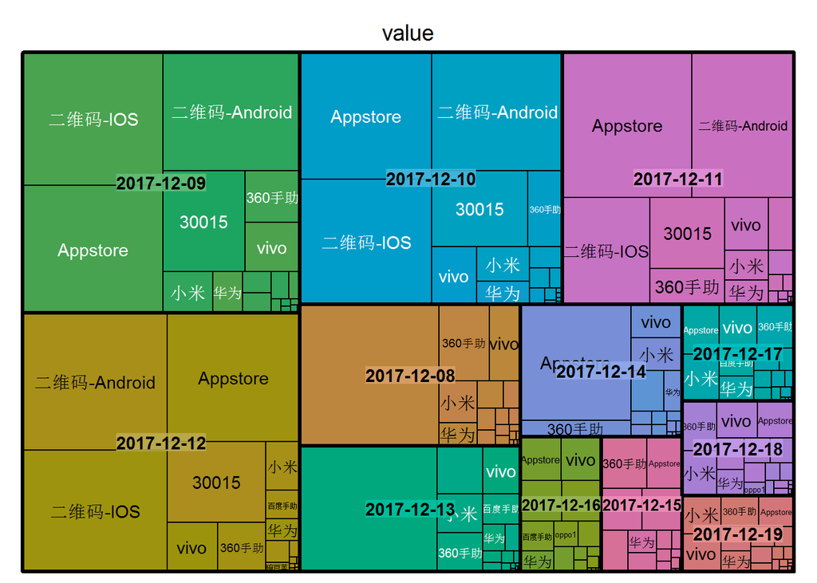

结构矩形树图，大矩形为日期，小矩形为具体渠道，按从大到小的顺序，从上到下，从左到右排列

# 转化问题

## 每日订单数

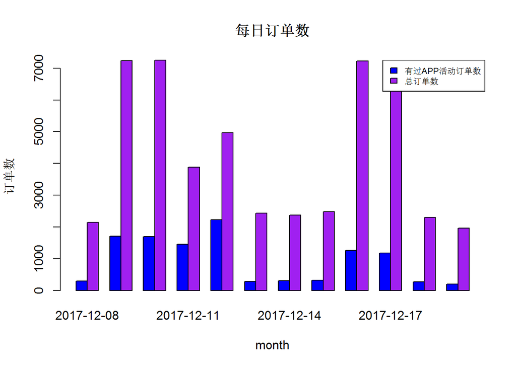

在APP上有过活动的人生成的订单占比较少，12月9日，10日，12日，16日，17日几天订单多，线上比例也多

## 家装预约

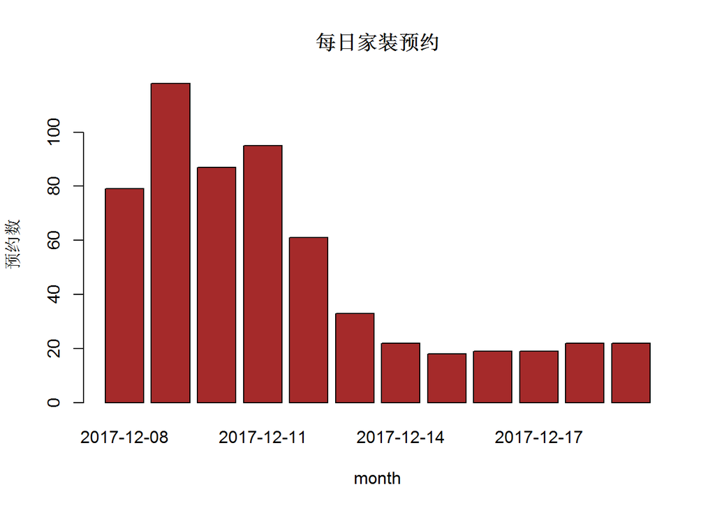

12月8日到12日的家装预约数比较高，之后明显降低

## 领券情况

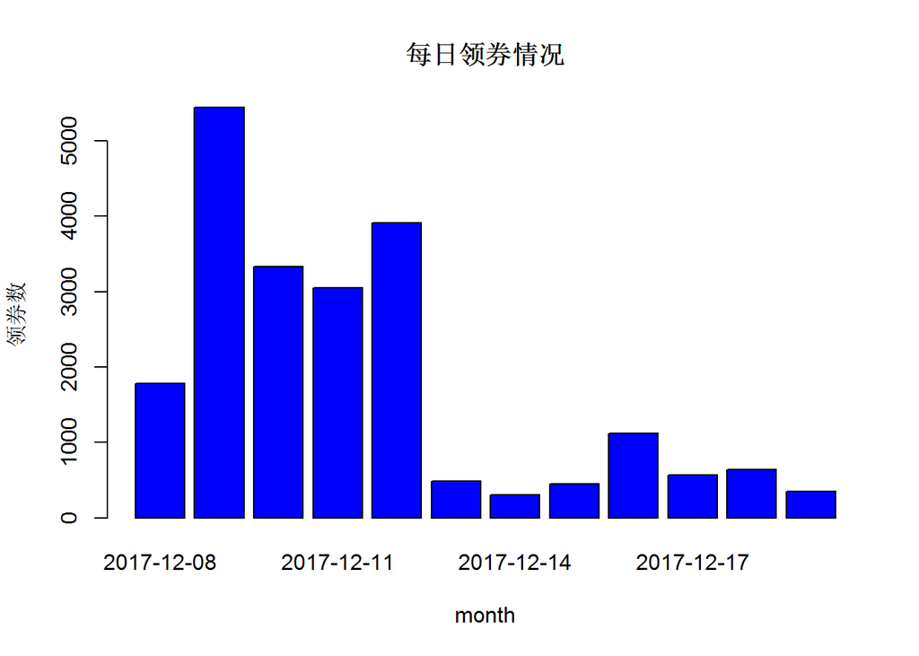

12月9日到12月12日，领券数明显较多，之后领券数明显较低

```
## [1] TRUE
```

```
## [1] TRUE
```